# Tidy Tuesday Week 13: Global Alcohol Consumption

Joe Stoica

6/29/2018

Tidy Tuesday is a data project hosted every week by the [R for Data Science learning community.](https://github.com/rfordatascience/tidytuesday) Anyone is welcome to participate, and are encouraged to colloborate and share their findings on Twitter with the [R4DS community](https://twitter.com/R4DScommunity).This week we are examining global alcohol consumption using the dataset from this [Fivethirtyeight article](https://fivethirtyeight.com/features/dear-mona-followup-where-do-people-drink-the-most-beer-wine-and-spirits/).

# Examining the Data

```r
head(consumption)
```

```
## # A tibble: 6 x 5
##   country   beer_servings spirit_servings wine_servings total_litres_of_p~
##   <chr>             <int>           <int>         <int>              <dbl>
## 1 Afghanis~             0               0             0                0
## 2 Albania              89             132            54                4.9
## 3 Algeria              25               0            14                0.7
## 4 Andorra             245             138           312               12.4
## 5 Angola              217              57            45                5.9
## 6 Antigua ~           102             128            45                4.9
```

The above table shows the first six rows in our data frame. We are given a country, and the number of servings of beer, spirits, and wine consumed by that country, as well as the total liters of pure alcohol. It is important to note that this column is not the sum of servings.

# Remaking the Table from the 538 Article

I wanted to start this week off by recreating the table shown in the article, which displays the top ten countries that consumes the most beer, spirits, and wine.

The first step is to separate our data frame into three smaller data frames by drink, get the top ten highest serving values, and then sort them from largest to smallest.

```r
beer <- consumption %>%
  select(country, Beer = beer_servings) %>%
  top_n(10) %>%
  arrange(desc(Beer))

spirit <- consumption %>%
  select(country, Spirit = spirit_servings) %>%
  top_n(10) %>%
  arrange(desc(Spirit))

wine <- consumption %>%
  select(country, Wine = wine_servings) %>%
  top_n(10) %>%
  arrange(desc(Wine))
```

Once we have those, we bind those three data frames into one and create our table using the kable function.

```r
alcohol <- bind_cols(beer, spirit, wine)

alcohol %>%
  kable(caption = "Who Drinks The Most Beer, Spirits, And Wine?",
        col.names = c("", "BEER", "", "SPIRIT", "", "WINE")) %>%
  kable_styling()
```

Who Drinks The Most Beer, Spirits, And Wine?

|  | BEER |  | SPIRIT |  | WINE |
| --- | --- | --- | --- | --- | --- |
| Namibia | 376 | Grenada | 438 | France | 370 |
| Czech Republic | 361 | Belarus | 373 | Portugal | 339 |
| Gabon | 347 | Haiti | 326 | Andorra | 312 |
| Germany | 346 | Russian Federation | 326 | Switzerland | 280 |
| Lithuania | 343 | St. Lucia | 315 | Denmark | 278 |
| Poland | 343 | Guyana | 302 | Slovenia | 276 |
| Venezuela | 333 | Slovakia | 293 | Luxembourg | 271 |
| Ireland | 313 | Dominica | 286 | Croatia | 254 |
| Palau | 306 | Thailand | 258 | Italy | 237 |
| Romania | 297 | Cook Islands | 254 | Equatorial Guinea | 233 |

# Highest Pure Alcohol Consumption

```r
top20 <- consumption %>%
  top_n(20) %>%
  select(country, Beer = beer_servings, Spirits = spirit_servings, Wine =  wine_servings) %>%
  gather(key = drink, value = qty, -country) %>%
  group_by(country)
```

Now that the data is tidied up, I thought a stacked bar chart would be a great way to display not only pure alcohol consumption, but also which kind of alcohol comprises that countries consumption.

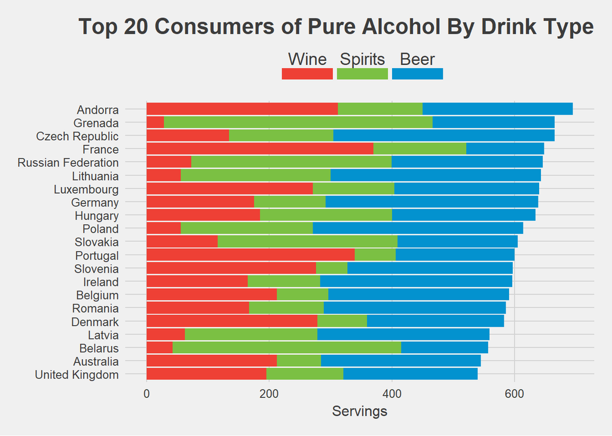

```r
plot <- ggplot(top20, aes(reorder(country, qty),
                          qty,
                          fill = drink)) +
  geom_bar(stat = "identity")+
  theme_fivethirtyeight() +
  coord_flip() +
  theme(axis.title = element_text(),
        axis.title.y = element_blank(),
        plot.title = element_text(hjust = 1),
        legend.position = "top",
        legend.text = element_text(size = 14)) +
  ylab("Servings") +
  ggtitle("Top 20 Consumers of Pure Alcohol By Drink Type") +
  guides(fill = guide_legend(keywidth = 3,
                             keyheight = .75,
                             title=NULL,
                             label.position = "top",
                             label.hjust = 0.5,
                             reverse = TRUE)) +
  scale_fill_manual(values = c("#0392cf", "#7bc043", "#ee4035"))

plot
```

We now have this lovely graphic. It has the highest consumer (Andorra) on top, and the lowest (the UK) on bottom, as well as their servings of alcohol. I think it is very interesing how each country is unique in how it drinks, because there are few similarities in the distribution of servings.

# Sankey Diagram

```r
library(devtools)
install_github("mages/googleVis")
require(googleVis)

top10 <- consumption %>%
  top_n(10) %>%
  select(country, Beer = beer_servings, Spirits = spirit_servings, Wine =  wine_servings) %>%
  gather(key = drink, value = qty, -country) %>%
  group_by(country)

sankey <- plot(gvisSankey(top10,
                          from = "country",
                          to = "drink",
                          weight = "qty",
                          option = "list"(
                            height = 750,
                            sankey = "{link:{color:{fill:'light blue'}}}"
                          )))
```

[output not shown]